# Regression Model Project

### Conclusion

In short, we can conclude that: 1. The type of transmission really has impact on the consumption of gasoline. Specifically, the auto transmission car will consume more gas. 2. Not all features in the dataset contributes a lot to the response variable. However, considering that the limited size of dataset, we cannot make a concrete conclusion regarding the inclusion of variables.

### Appendix

Pairs plot of variables.

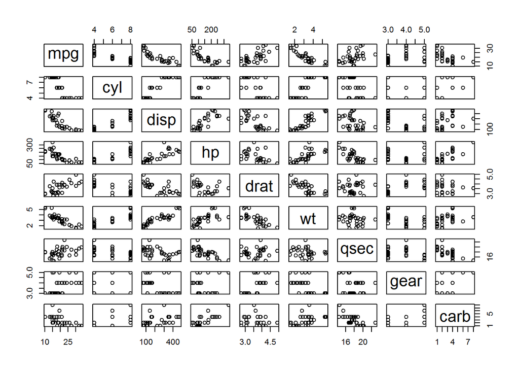